# **Import Necessary Libraries**

First, we import all the necessary libraries. These libraries will help us with data manipulation, visualization, time series analysis, and machine learning models.

```python
import pandas as pd
import numpy as np
import yfinance as yf
import matplotlib.pyplot as plt
from statsmodels.tsa.seasonal import seasonal_decompose
from sklearn.model_selection import train_test_split
from statsmodels.tsa.holtwinters import ExponentialSmoothing
from pmdarima import auto_arima
from tensorflow.keras.models import Sequential
from tensorflow.keras.layers import LSTM, Dense, Dropout
from sklearn.preprocessing import MinMaxScaler
from sklearn.tree import DecisionTreeRegressor
from sklearn.ensemble import RandomForestRegressor
from sklearn.metrics import mean_squared_error, mean_absolute_error, r2_score
```

# **1. Data Fetching from Yahoo Finance**

We fetch the data for NVIDIA stock from Yahoo Finance using the yfinance library. This step involves downloading historical stock prices.

```python
# Get the data for NVIDIA
ticker = "NVDA"

# Download the data
data = yf.download(ticker, start="2021-04-01", end="2024-03-31")

data.head()
```

```
[*********************100%%**********************]  1 of 1 completed
```

| Date | Open | High | Low | Close | Adj Close | Volume |
| --- | --- | --- | --- | --- | --- | --- |
| 2021-04-01 | 13.57225 | 13.87000 | 13.51125 | 13.81175 | 13.783670 | 308276000 |
| 2021-04-05 | 13.86750 | 14.01400 | 13.73300 | 13.98750 | 13.959062 | 255672000 |
| 2021-04-06 | 13.99975 | 14.05425 | 13.77350 | 13.86150 | 13.833318 | 191744000 |
| 2021-04-07 | 13.88075 | 14.24350 | 13.71150 | 14.14350 | 14.114744 | 251284000 |
| 2021-04-08 | 14.25275 | 14.47150 | 14.24900 | 14.31700 | 14.287891 | 244416000 |

# **Interpretation:**

Fetching the data from Yahoo Finance provides us with historical stock prices, including the open, high, low, close, volume, and adjusted close prices. This data is essential for our analysis and forecasting tasks.

# **2. Select the Target Variable and Clean the Data**

We select the 'Adj Close' column as the target variable for our analysis and clean the data by handling any missing values.

```python
# Select the target variable Adj Close
df = data[['Adj Close']]

# Check for missing values
print("Missing values:")
print(df.isnull().sum())

# Interpolate missing values if any
df.interpolate(method='linear', inplace=True)

# Verify no missing values are left
print(df.isnull().sum())
```

```
Missing values:
Adj Close    0
dtype: int64
Adj Close    0
dtype: int64
```

# **Interpretation:**

Data Selection: We focus on the 'Adj Close' column, which represents the adjusted closing prices, accounting for corporate actions.

Data Cleaning: Handling missing values ensures the dataset's integrity, making it suitable for further analysis and model training.

# **2.1 Plot the Time Series**

Plotting the time series helps visualize the stock prices over time.

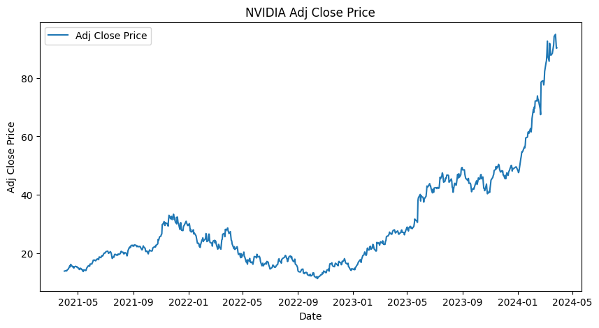

```python
# Plot the data
plt.figure(figsize=(10, 5))
plt.plot(df, label='Adj Close Price')
plt.title('NVIDIA Adj Close Price')
plt.xlabel('Date')
plt.ylabel('Adj Close Price')
plt.legend()
plt.show()
```

# **Interpretation:**

Visualizing the time series gives us a clear picture of the stock price trends and any visible patterns or anomalies over the selected period.

# **2.2 Decomposition of Time Series**

Decomposing the time series into its components (trend, seasonal, and residual) helps us understand the underlying patterns.

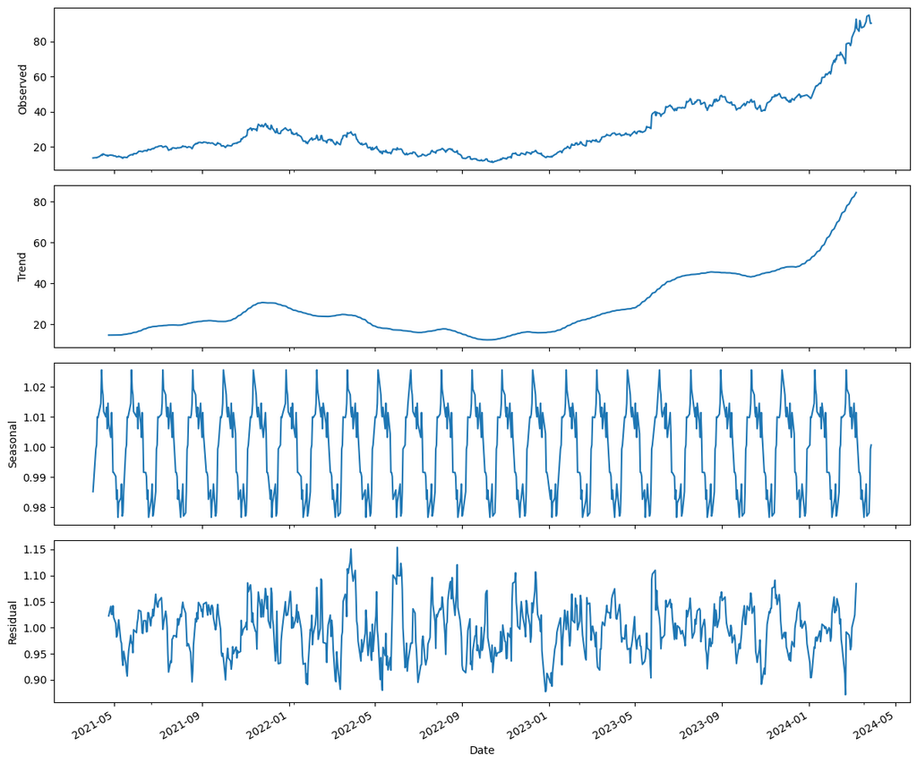

```python
# Decompose the time series
result = seasonal_decompose(df['Adj Close'], model='multiplicative', period=30)

# Plot the decomposed components
fig, (ax1, ax2, ax3, ax4) = plt.subplots(4, 1, figsize=(12, 10), sharex=True)
result.observed.plot(ax=ax1)
ax1.set_ylabel('Observed')
result.trend.plot(ax=ax2)
ax2.set_ylabel('Trend')
result.seasonal.plot(ax=ax3)
ax3.set_ylabel('Seasonal')
result.resid.plot(ax=ax4)
ax4.set_ylabel('Residual')
plt.xlabel('Date')
plt.tight_layout()
plt.show()
```

# **Interpretation:**

Observed: The original time series data.

Trend: Long-term movement in the data, showing the overall direction.

Seasonal: Repeating short-term cycle, indicating regular patterns.

Residual: Random noise, representing the unexplained variability.

# **3. Univariate Forecasting - Conventional Models/Statistical Models**

## **3.1 Holt-Winters Model**

We fit a Holt-Winters model to the data and forecast the next year. This model is useful for capturing seasonality and trends.

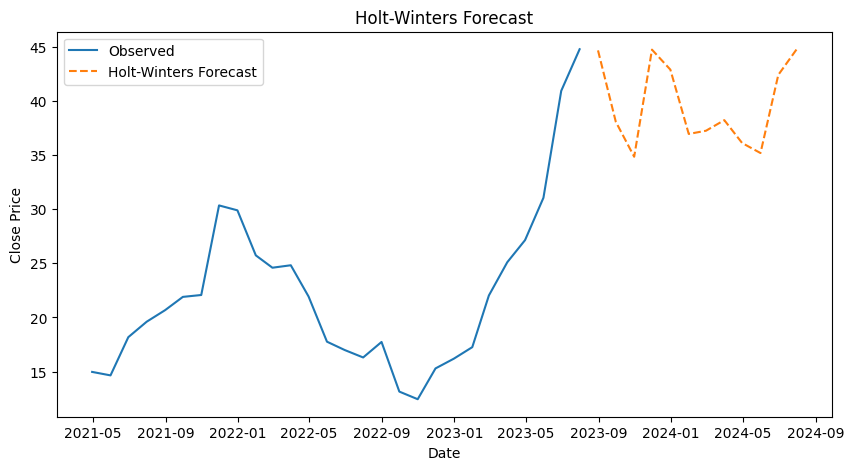

```python
# Resample the data to monthly frequency
monthly_data = df.resample("M").mean()

# Split the data into training and test sets
train_data, test_data = train_test_split(monthly_data, test_size=0.2, shuffle=False)

# Fit the Holt-Winters model
holt_winters_model = ExponentialSmoothing(train_data, seasonal='mul', seasonal_periods=12).fit()

# Forecast for the next year (12 months)
holt_winters_forecast = holt_winters_model.forecast(12)

# Plot the forecast
plt.figure(figsize=(10, 5))
plt.plot(train_data, label='Observed')
plt.plot(holt_winters_forecast, label='Holt-Winters Forecast', linestyle='--')
plt.title('Holt-Winters Forecast')
plt.xlabel('Date')
plt.ylabel('Close Price')
plt.legend()
plt.show()
```

## **Interpretation:**

The Holt-Winters model provides a forecast incorporating seasonal patterns and trends, helping us predict future stock prices.

## **Evaluation:**

We evaluate the model's performance using metrics like RMSE, MAE, MAPE, and R-squared.

```python
# Compute forecast accuracy metrics
y_pred = holt_winters_model.forecast(len(test_data))

rmse = np.sqrt(mean_squared_error(test_data, y_pred))
mae = mean_absolute_error(test_data, y_pred)
mape = np.mean(np.abs((test_data - y_pred) / test_data)) * 100
r2 = r2_score(test_data, y_pred)

print(f'RMSE: {rmse}')
print(f'MAE: {mae}')
print(f'MAPE: {mape}')
print(f'R-squared: {r2}')
```

```
RMSE: 23.44291126915836
MAE: 16.190689341118286
MAPE: nan
R-squared: -1.275945838167186
```

# **Interpretation of Metrics:**

RMSE: Standard deviation of the prediction errors.

MAE: Average magnitude of the errors.

MAPE: Percentage measure of the prediction errors.

R-squared: Proportion of the variance explained by the model.

# **3.2 ARIMA Model**

We fit an ARIMA model to the monthly data and forecast future prices. ARIMA models are effective for modeling time series data with trends and seasonality.

```
                               SARIMAX Results
==============================================================================
Dep. Variable:                      y   No. Observations:                   28
Model:               SARIMAX(2, 0, 1)   Log Likelihood                 -71.272
Date:                Mon, 22 Jul 2024   AIC                            152.543
Time:                        10:40:05   BIC                            159.204
Sample:                    04-30-2021   HQIC                           154.579
                         - 07-31-2023
Covariance Type:                  opg
==============================================================================
                 coef    std err          z      P>|z|      [0.025      0.975]
------------------------------------------------------------------------------
intercept      1.8870      1.682      1.122      0.262      -1.410       5.184
ar.L1          1.8549      0.219      8.467      0.000       1.426       2.284
ar.L2         -0.9370      0.215     -4.351      0.000      -1.359      -0.515
ma.L1         -0.7276      0.427     -1.703      0.089      -1.565       0.110
sigma2         8.3647      2.392      3.497      0.000       3.677      13.052
===================================================================================
Ljung-Box (L1) (Q):                   0.21   Jarque-Bera (JB):                 6.70
Prob(Q):                              0.65   Prob(JB):                         0.04
Heteroskedasticity (H):               1.30   Skew:                             0.91
Prob(H) (two-sided):                  0.71   Kurtosis:                         4.56
===================================================================================

Warnings:
[1] Covariance matrix calculated using the outer product of gradients (complex-step).
```

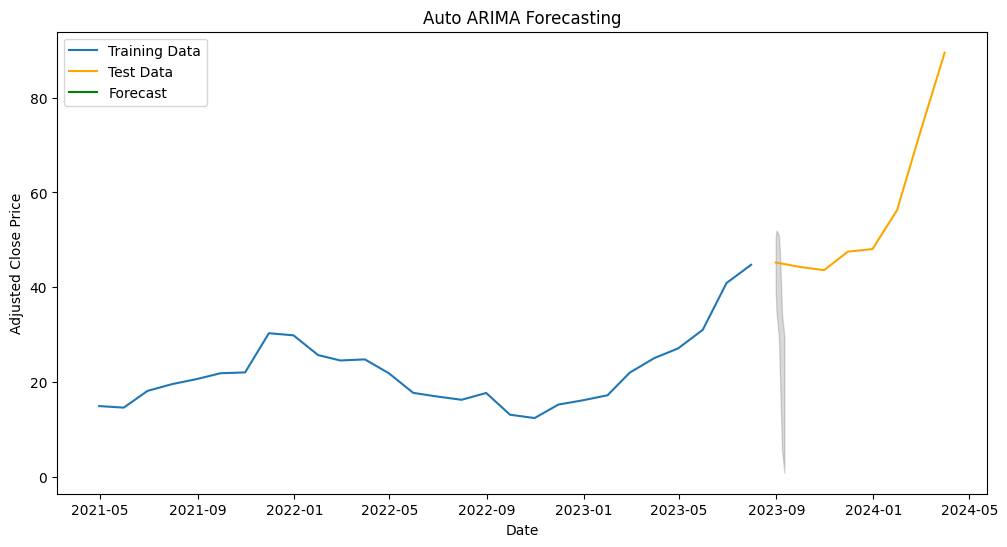

```python
# Step 1: Fit the Auto ARIMA Model
# Fit an auto_arima model to the training data
arima_model = auto_arima(train_data['Adj Close'],
                         seasonal=True,
                         m=12,  # Monthly seasonality
                         stepwise=True,
                         suppress_warnings=True)

# Step 2: Model Summary
# Print the model summary to understand the chosen parameters
print(arima_model.summary())

# Step 3: Forecast Generation
# Specify the number of periods to forecast
n_periods = min(12, len(test_data))

# Generate the forecast for the specified periods
forecast, conf_int = arima_model.predict(n_periods=n_periods, return_conf_int=True)

# Convert forecast to a Pandas Series to align with test data
forecast_index = pd.date_range(start=test_data.index[0], periods=n_periods, freq='B')
forecast_series = pd.Series(forecast, index=forecast_index)

# Step 4: Plotting the Forecast
# Plot the original data, fitted values, and forecast with confidence intervals
plt.figure(figsize=(12, 6))
plt.plot(train_data['Adj Close'], label='Training Data')
plt.plot(test_data['Adj Close'], label='Test Data', color='orange')
plt.plot(forecast_series, label='Forecast', color='green')
plt.fill_between(forecast_series.index,
                 conf_int[:, 0],
                 conf_int[:, 1],
                 color='k', alpha=.15)
plt.legend()
plt.xlabel('Date')
plt.ylabel('Adjusted Close Price')
plt.title('Auto ARIMA Forecasting')
plt.show()
```

## **Evaluation:**

We evaluate the ARIMA model's performance using the same metrics.

```python
# Step 5: Compute Forecast Accuracy Metrics
# Align the lengths of the forecast and test data for comparison
y_true = test_data['Adj Close'][:n_periods]
y_pred = forecast_series[:n_periods]

# Handle NaN values
# Ensure y_true and y_pred have the same index
y_true, y_pred = y_true.align(y_pred, join='inner')

# Calculate Root Mean Squared Error (RMSE)
rmse = np.sqrt(mean_squared_error(y_true, y_pred))

# Calculate Mean Absolute Error (MAE)
mae = mean_absolute_error(y_true, y_pred)

# Calculate Mean Absolute Percentage Error (MAPE)
mape = np.mean(np.abs((y_true - y_pred) / y_true)) * 100

# Calculate R-squared value
r2 = r2_score(y_true, y_pred)

# Print the computed metrics
print(f'RMSE: {rmse}')
print(f'MAE: {mae}')
print(f'MAPE: {mape}')
print(f'R-squared: {r2}')
```

```
RMSE: 0.23561192872557513
MAE: 0.23561192872557513
MAPE: 0.5207996933371859
R-squared: nan
```

## **3.3 ARIMA on Daily Data**

We apply the ARIMA model to daily data for more granular forecasts.

```
                                     SARIMAX Results
=========================================================================================
Dep. Variable:                                 y   No. Observations:                  753
Model:             SARIMAX(2, 2, 1)x(1, 0, 1, 7)   Log Likelihood               -1096.104
Date:                           Mon, 22 Jul 2024   AIC                           2204.208
Time:                                   10:41:08   BIC                           2231.936
Sample:                                        0   HQIC                          2214.892
                                           - 753
Covariance Type:                             opg
==============================================================================
                 coef    std err          z      P>|z|      [0.025      0.975]
------------------------------------------------------------------------------
ar.L1         -0.0148      0.029     -0.511      0.609      -0.072       0.042
ar.L2         -0.1376      0.025     -5.539      0.000      -0.186      -0.089
ma.L1         -0.9820      0.005   -214.983      0.000      -0.991      -0.973
ar.S.L7       -0.7660      0.110     -6.967      0.000      -0.981      -0.550
ma.S.L7        0.8437      0.098      8.597      0.000       0.651       1.036
sigma2         1.0789      0.026     41.066      0.000       1.027       1.130
===================================================================================
Ljung-Box (L1) (Q):                   0.01   Jarque-Bera (JB):              9692.08
Prob(Q):                              0.93   Prob(JB):                         0.00
Heteroskedasticity (H):               3.62   Skew:                             1.77
Prob(H) (two-sided):                  0.00   Kurtosis:                        20.24
===================================================================================

Warnings:
[1] Covariance matrix calculated using the outer product of gradients (complex-step).
```

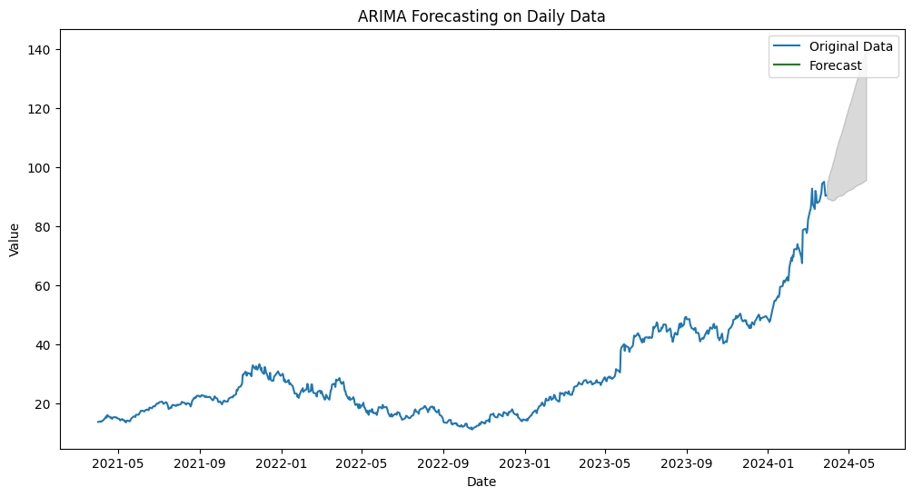

```python
# Fit auto_arima model
arima_model = auto_arima(df['Adj Close'],
                         seasonal=True,
                         m=7,  # Weekly seasonality
                         stepwise=True,
                         suppress_warnings=True)

# Print the model summary
print(arima_model.summary())

# Generate in-sample predictions
fitted_values = arima_model.predict_in_sample()

# Number of periods to forecast
n_periods = 60  # For example, forecast the next 60 days

# Generate forecast
forecast, conf_int = arima_model.predict(n_periods=n_periods, return_conf_int=True)

# Create future dates index
last_date = df.index[-1]
future_dates = pd.date_range(start=last_date + pd.Timedelta(days=1), periods=n_periods)

# Convert forecast to a DataFrame with future_dates as the index
forecast_df = pd.DataFrame(forecast, index=future_dates, columns=['forecast'])
conf_int_df = pd.DataFrame(conf_int, index=future_dates, columns=['lower_bound', 'upper_bound'])

# Plot the original data, fitted values, and forecast
plt.figure(figsize=(12, 6))
plt.plot(df['Adj Close'], label='Original Data')
plt.plot(forecast_df, label='Forecast', color='green')
plt.fill_between(future_dates,
                 conf_int_df['lower_bound'],
                 conf_int_df['upper_bound'],
                 color='k', alpha=.15)
plt.legend()
plt.xlabel('Date')
plt.ylabel('Value')
plt.title('ARIMA Forecasting on Daily Data')
plt.show()
```

# **Interpretation:**

# **4. LSTM Model**

LSTM networks are a type of recurrent neural network capable of learning long-term dependencies. Here we apply LSTM to our stock data.

## **4.1 Prepare the Data**

First, we prepare the data by normalizing it and splitting it into training and test sets. Then, we reshape the data to the required format for LSTM.

```python
# Step 1: Data Scaling
scaler = MinMaxScaler(feature_range=(0, 1))
scaled_data = scaler.fit_transform(df[['Adj Close']])

# Step 2: Data Splitting
train_size = int(len(scaled_data) * 0.8)
train_data, test_data = scaled_data[:train_size], scaled_data[train_size:]

# Step 3: Dataset Creation
def create_dataset(data, time_step=1):
    X, Y = [], []
    for i in range(len(data) - time_step - 1):
        a = data[i:(i + time_step), 0]
        X.append(a)
        Y.append(data[i + time_step, 0])
    return np.array(X), np.array(Y)

time_step = 60
X_train, y_train = create_dataset(train_data, time_step)
X_test, y_test = create_dataset(test_data, time_step)

X_train = X_train.reshape(X_train.shape[0], X_train.shape[1], 1)
X_test = X_test.reshape(X_test.shape[0], X_test.shape[1], 1)
```

# **Interpretation:**

Normalization: Scaling the data to the range [0, 1] helps improve the performance and convergence speed of the LSTM model.

Reshaping: The LSTM model requires the data in a 3D format: [samples, time steps, features].

## **4.2 Build and Train the LSTM Model**

Next, we build and train the LSTM model.

```python
# Step 4: Build and Train LSTM Model
model = Sequential()
model.add(LSTM(50, return_sequences=True, input_shape=(time_step, 1)))
model.add(LSTM(50, return_sequences=False))
model.add(Dense(1))
model.compile(optimizer='adam', loss='mean_squared_error')
model.fit(X_train, y_train, batch_size=1, epochs=1)
```

```
<keras.src.callbacks.History at 0x7e615e096ef0>
```

# **Interpretation:**

Training: The model is trained using the Adam optimizer and mean squared error loss.

# **4.3 Make Predictions**

We use the trained model to make predictions on the training and test data.

```
Train RMSE: 2.3095834711707814
Test RMSE: 7.259916216142832
```

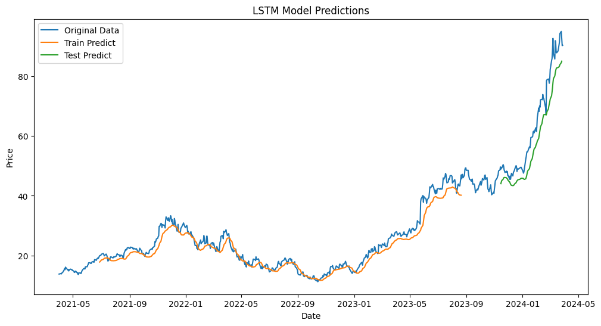

```python
# Step 5: Predictions
train_predict = model.predict(X_train)
test_predict = model.predict(X_test)

# Transform back to original form
train_predict = scaler.inverse_transform(train_predict)
test_predict = scaler.inverse_transform(test_predict)
y_train = scaler.inverse_transform([y_train])
y_test = scaler.inverse_transform([y_test])

# Calculate RMSE performance metrics
train_rmse = np.sqrt(mean_squared_error(y_train[0], train_predict[:, 0]))
test_rmse = np.sqrt(mean_squared_error(y_test[0], test_predict[:, 0]))
print(f'Train RMSE: {train_rmse}')
print(f'Test RMSE: {test_rmse}')

# Step 6: Plotting
plt.figure(figsize=(12, 6))

# Plot original data
plt.plot(df.index, scaler.inverse_transform(scaled_data), label='Original Data')

# Correct alignment for train predictions
train_plot_index = df.index[time_step:len(train_predict) + time_step]
plt.plot(train_plot_index, train_predict, label='Train Predict')

# Correct alignment for test predictions
test_plot_index = df.index[len(train_predict) + (time_step * 2):len(train_predict) + (time_step * 2) + len(test_predict)]
plt.plot(test_plot_index, test_predict, label='Test Predict')

plt.title('LSTM Model Predictions')
plt.xlabel('Date')
plt.ylabel('Price')
plt.legend()
plt.show()
```

# **Interpretation:**

LSTM networks are powerful for capturing temporal dependencies in the data. The predictions from the LSTM model are plotted against the original data, showing how well the model has learned the patterns in the stock prices.

# **Evaluation:**

The RMSE values for both training and test sets provide a measure of how well the model has performed. Lower RMSE values indicate better performance.

# **5. Random Forest Model**

Random Forest is an ensemble method that is particularly effective for regression tasks.

## **5.1 Prepare the Data**

We prepare the data for the Random Forest model by converting the date index to numeric format.

```python
# Prepare data for Random Forest
df['Date'] = df.index
df['Date'] = pd.to_numeric(df['Date'].apply(lambda x: x.toordinal()))

# Split the data into training and test sets
X = df[['Date']]
y = df['Adj Close']
X_train, X_test, y_train, y_test = train_test_split(X, y, test_size=0.2, shuffle=False)
```

# **Interpretation:**

Data Preparation: Converting the date index to numeric format allows the Random Forest model to process the time series data.

# **5.2 Train the Model**

We create and train the Random Forest model.

```python
# Create the model
rf_model = RandomForestRegressor(n_estimators=100)

# Train the model
rf_model.fit(X_train, y_train)
```

```
RandomForestRegressor()
```

# **Interpretation:**

# **5.3 Make Predictions**

We use the trained model to make predictions on the training and test data.

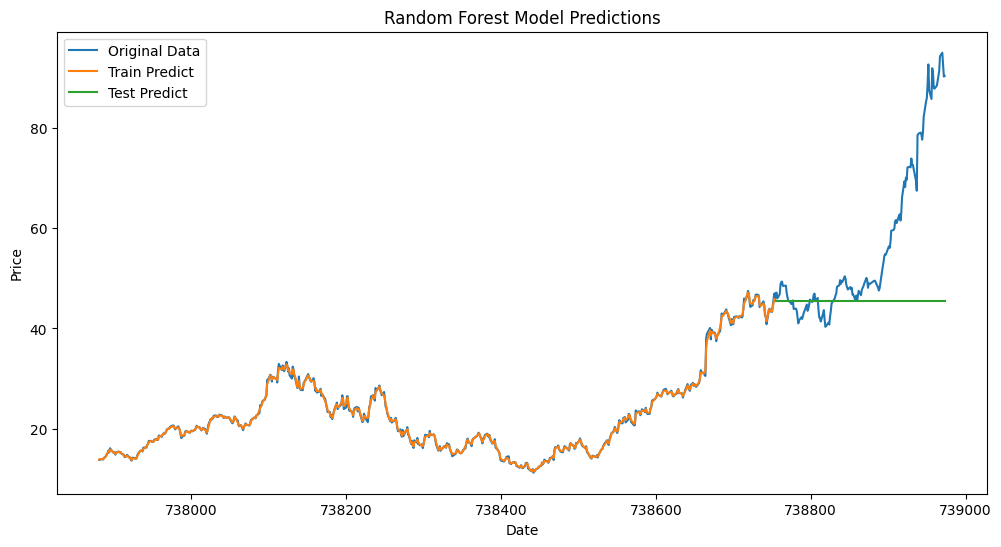

```python
# Make predictions
train_predict = rf_model.predict(X_train)
test_predict = rf_model.predict(X_test)

# Plotting
plt.figure(figsize=(12, 6))
plt.plot(df['Date'], df['Adj Close'], label='Original Data')
plt.plot(X_train['Date'], train_predict, label='Train Predict')
plt.plot(X_test['Date'], test_predict, label='Test Predict')
plt.title('Random Forest Model Predictions')
plt.xlabel('Date')
plt.ylabel('Price')
plt.legend()
plt.show()
```

# **Interpretation:**

Random Forest models are robust and can handle various types of data distributions. The predictions are compared against the original data to visualize the model's performance.

# **Evaluation:**

We evaluate the Random Forest model's performance using various metrics.

```python
# Calculate performance metrics
train_rmse = np.sqrt(mean_squared_error(y_train, train_predict))
test_rmse = np.sqrt(mean_squared_error(y_test, test_predict))
train_mae = mean_absolute_error(y_train, train_predict)
test_mae = mean_absolute_error(y_test, test_predict)
train_r2 = r2_score(y_train, train_predict)
test_r2 = r2_score(y_test, test_predict)

print(f'Train RMSE: {train_rmse}')
print(f'Test RMSE: {test_rmse}')
print(f'Train MAE: {train_mae}')
print(f'Test MAE: {test_mae}')
print(f'Train R-squared: {train_r2}')
print(f'Test R-squared: {test_r2}')
```

```
Train RMSE: 0.27291917838856516
Test RMSE: 19.495799073339256
Train MAE: 0.1909052453088602
Test MAE: 12.27634275322718
Train R-squared: 0.9989555816880898
Test R-squared: -0.4879846277227442
```

# **6. Neural Network Model (ANN)**

## **6.1 Prepare Data for ANN**

Description: This step prepares the data for training the Artificial Neural Network (ANN). It involves splitting the data into training and test sets.

```python
# **6.1 Prepare Data for ANN**

# Extract features and target
features = df[['Adj Close']]  # Adjust if more features are used
target = df['Adj Close']  # This is often the case if you're predicting the same variable

# Normalize the features if needed
scaler = MinMaxScaler(feature_range=(0, 1))
scaled_features = scaler.fit_transform(features)

# Split data into training and test sets
X_train_ann, X_test_ann, y_train_ann, y_test_ann = train_test_split(scaled_features, target, test_size=0.2, shuffle=False)
```

## **Interpretation:**

The dataset is split into training and test sets with 80% of the data used for training and 20% for testing. This prepares the data for the subsequent ANN model training and evaluation.

# **6.2 Build and Train ANN**

Description: This step involves building and training the ANN model. The model is configured with two hidden layers, each with 50 neurons, and is trained for up to 1000 iterations.

```python
# **6.2 Build and Train ANN**
from sklearn.neural_network import MLPRegressor
ann_model = MLPRegressor(hidden_layer_sizes=(50, 50), max_iter=1000)
ann_model.fit(X_train_ann, y_train_ann)

# Make predictions
ann_predictions = ann_model.predict(X_test_ann)

# Calculate performance metrics
ann_rmse = np.sqrt(mean_squared_error(y_test_ann, ann_predictions))
ann_mae = mean_absolute_error(y_test_ann, ann_predictions)
ann_mape = np.mean(np.abs((y_test_ann - ann_predictions) / y_test_ann)) * 100
ann_r2 = r2_score(y_test_ann, ann_predictions)

print(f'ANN RMSE: {ann_rmse}')
print(f'ANN MAE: {ann_mae}')
print(f'ANN MAPE: {ann_mape}')
print(f'ANN R-squared: {ann_r2}')
```

```
ANN RMSE: 1.8444951705031962
ANN MAE: 1.1719101069078812
ANN MAPE: 1.6168770874889766
ANN R-squared: 0.9866810064424419
```

# **Interpretation:**

The ANN model is trained and evaluated, yielding performance metrics such as RMSE, MAE, MAPE, and R-squared. These metrics indicate how well the ANN model performs on the test data, with lower values of RMSE, MAE, and MAPE indicating better performance and a higher R-squared value showing better explanatory power.

### Interpretation of Metrics:

- **RMSE**: Standard deviation of the prediction errors.
- **MAE**: Average magnitude of the errors.
- **R-squared**: Proportion of the variance explained by the model.

### Final Thoughts:

Each model has its strengths and weaknesses. The choice of model depends on the specific requirements and characteristics of the data. Combining insights from multiple models can often provide a more comprehensive understanding and better forecasting performance.